“Vaginal explant herpes infection experiment”

```
## Inputting the data ...
## Perform Quality Control assessment of the LumiBatch object ...
```

EXPERIMENT NOTES 6 samples failed when the microarray was run 6,33,34,35,45,63 and two failed QC (36,64). The failed were left out of the finalReport filethat we got from shared resources and we will leave all 8 out of the analysis too.

ALSO

The first 5 samples in the micrarray data are T cells that were exposed to Tenofovir. These will be analyzed separately and can be separated from the vaginal explant data.

SOME PLOTS OF NON NORMALIZED DATA: density plot, cdf plot

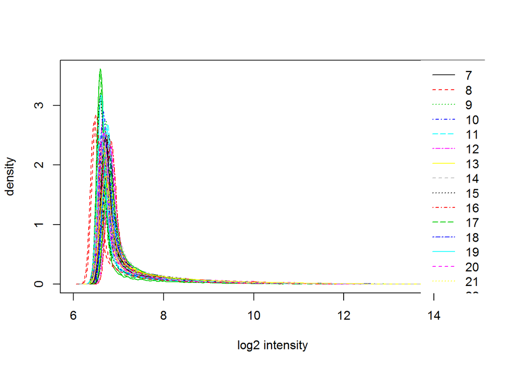

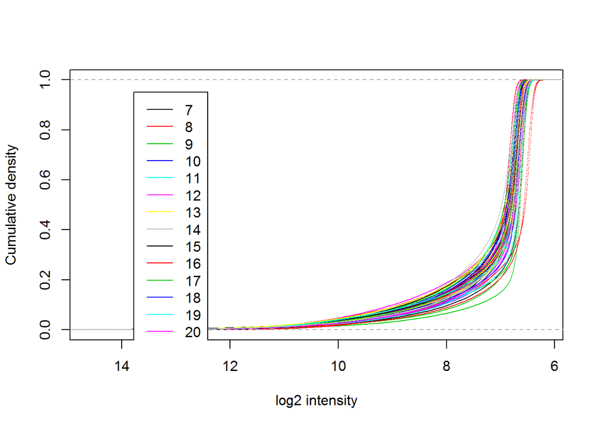

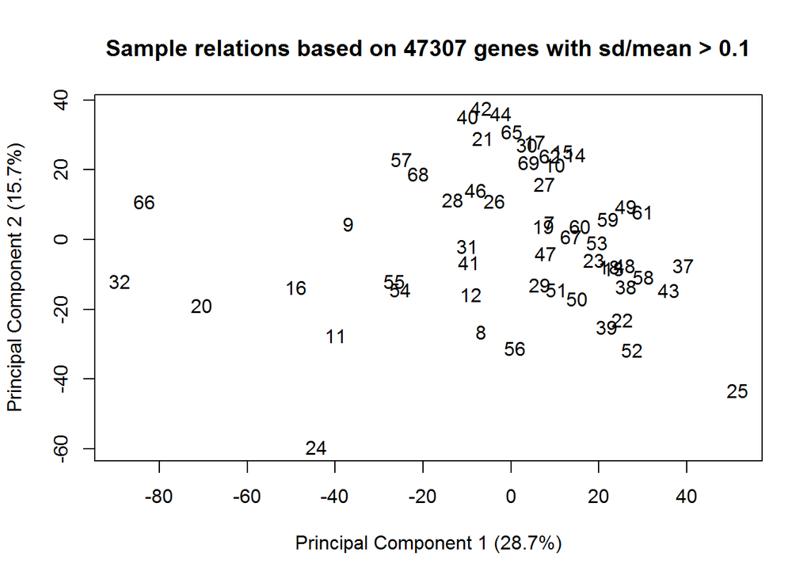

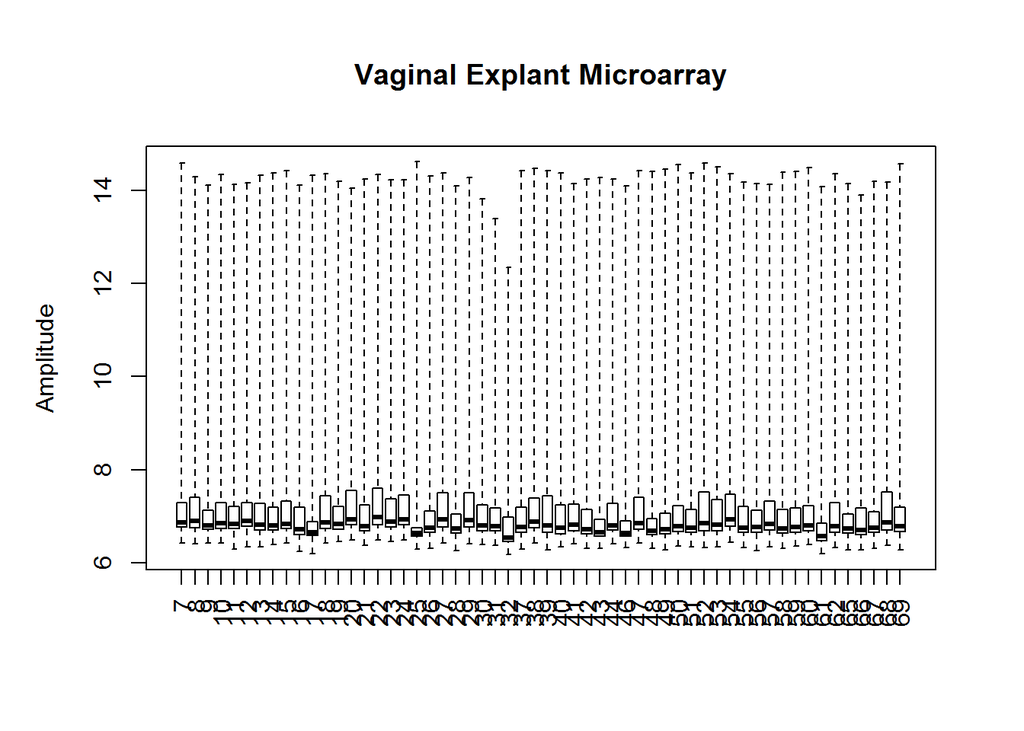

[output not shown]

[output not shown]

```
## Perform Quality Control assessment of the LumiBatch object ...
```

PLOTS OF NORMALIZED DATA

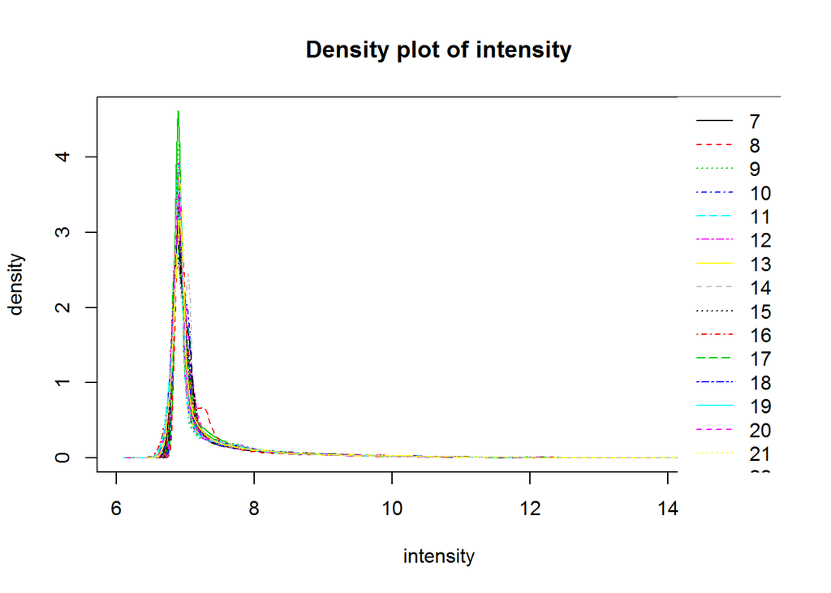

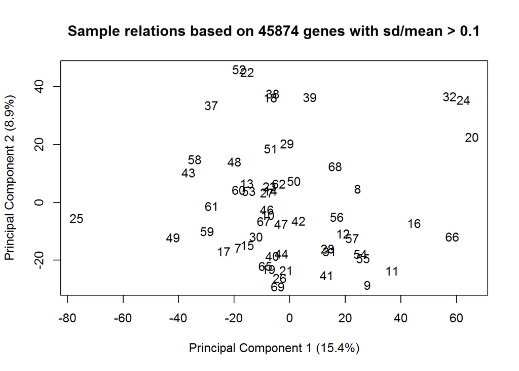

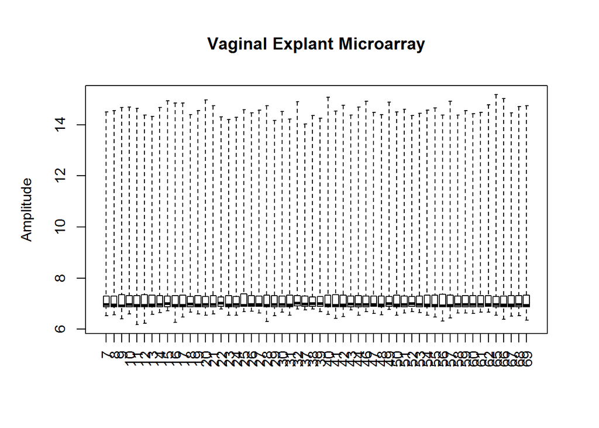

FILTERING PROBES BASED ON DETECTION Limma suggests to keep probes that are expressed above bg on at least n arrays where n is smallest number of replicates assigned to any of the treatment combinations.

Our treatment combinations are TissueID/Treatment/Time We have 7 Tissue IDs x 3 Treatments x 3 time points=63 so the smallest number of replicates possible for any of those 63 arrays is 7

how many probes did we have before and after filtering?

```
##          detection exprs se.exprs
## Features     47323 47323    47323
## Samples         56    56       56
```

```
##          detection exprs se.exprs
## Features     27126 27126    27126
## Samples         56    56       56
```

how many removed?

```
##          detection exprs se.exprs
## Features     20197 20197    20197
## Samples          0     0        0
```

How many probes are up and down regulated for each contrast?

```
## Source: local data frame [6 x 3]
##
##           variable  down    up
##             (fctr) (int) (int)
## 1   V186.3vsMock.3    12    10
## 2   V186.8vsMock.8     8     1
## 3 V186.24vsMock.24   993   534
## 4   SD90.3vsMock.3     2     0
## 5   SD90.8vsMock.8     0     0
## 6 SD90.24vsMock.24     0     0
```

Heatmaps of the first 4 contrasts: V186 vs mock at 3hr, 8hr, and 24 hrs, SD90 vs Mock at 3 hrs

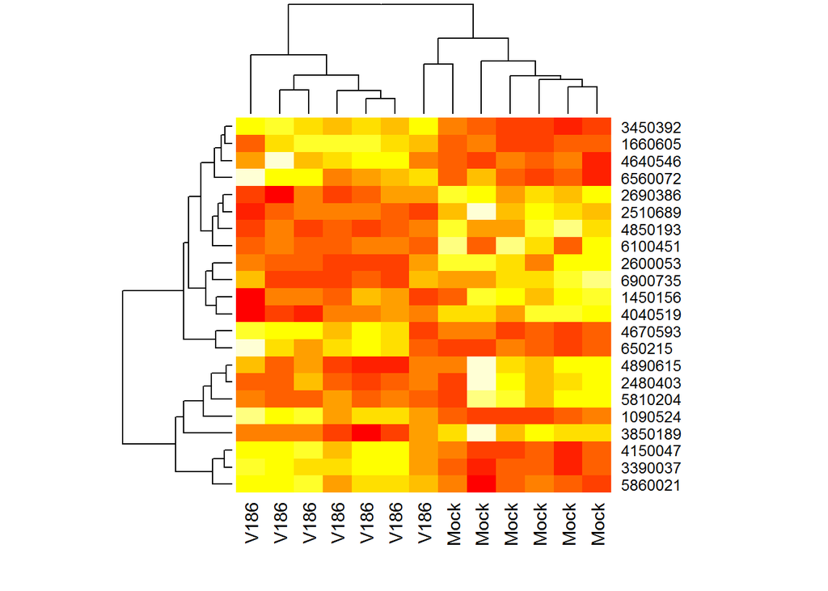

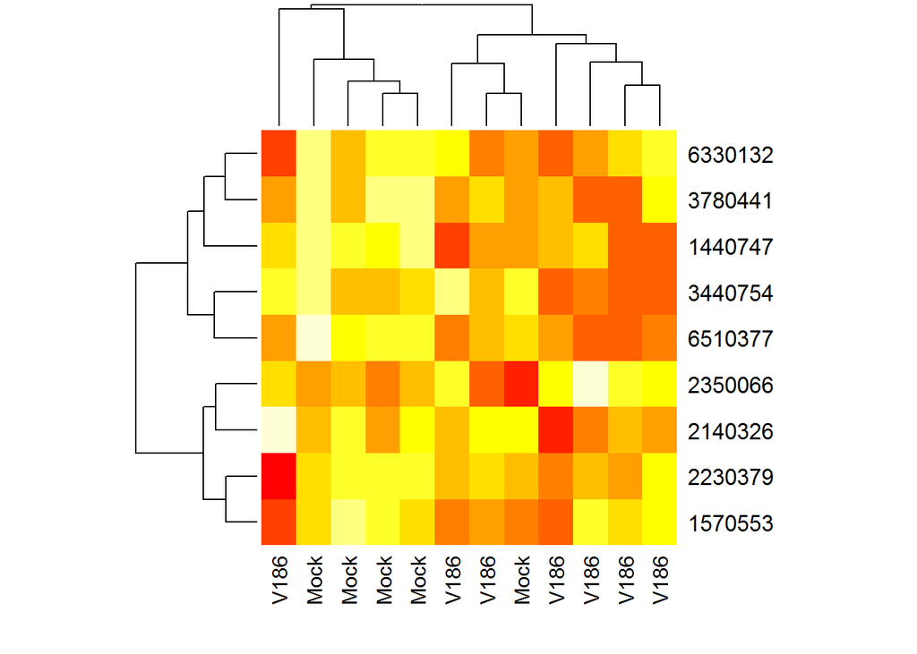

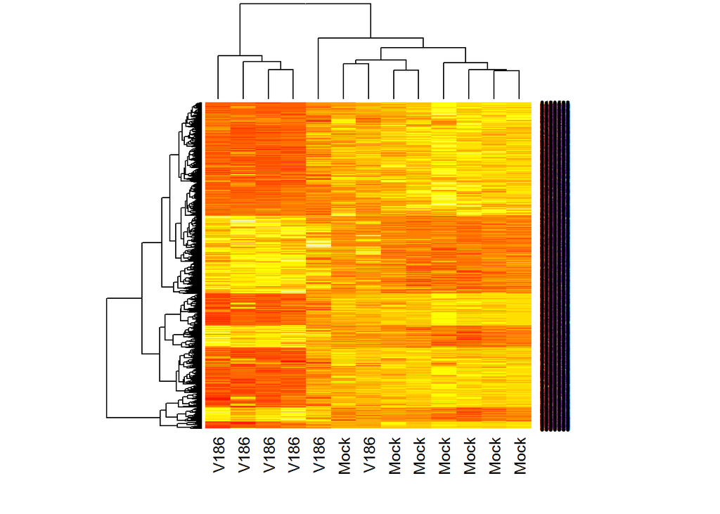

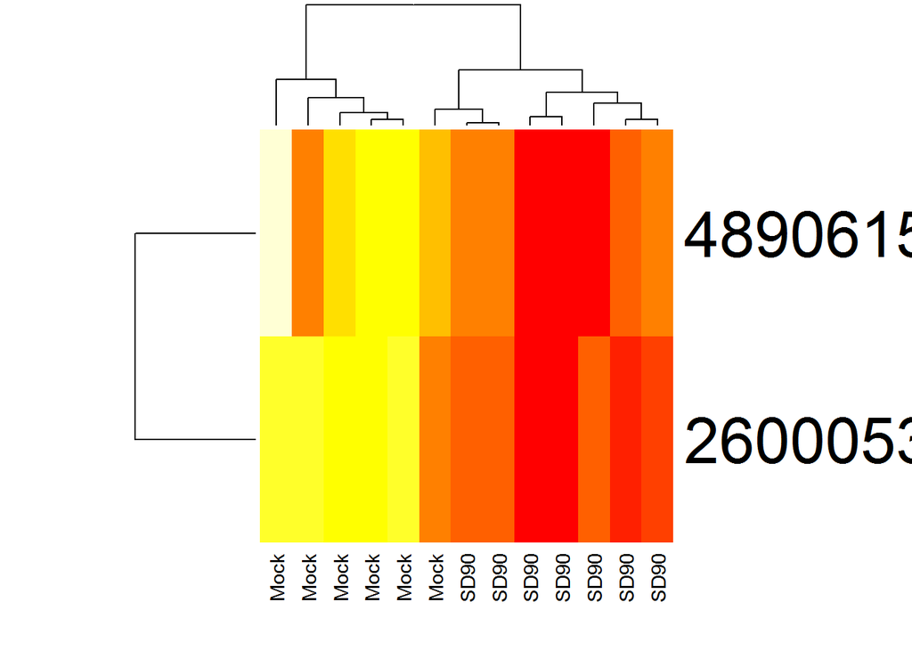

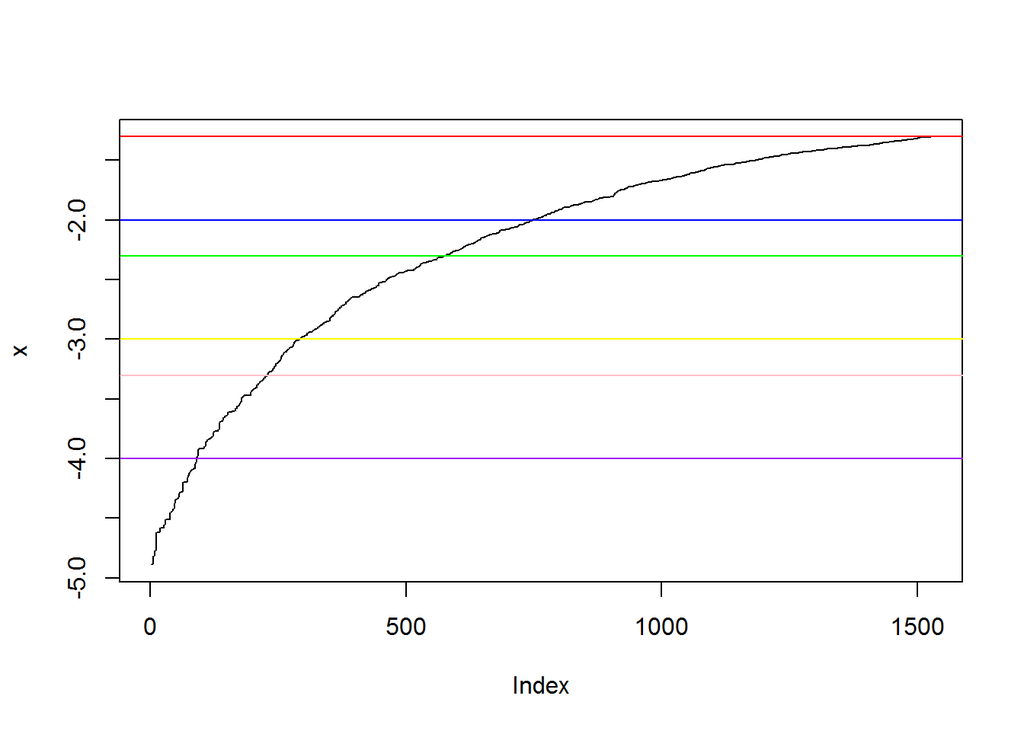

Looks like there would still be a lot (hundreds)of DE probes for the v186 24hr comparison if reduced the adj p val cutoff to 0.01, but that would reduce the # of DE probes in the v186.3 to ~2 and v186.8 to ~3. The SD90.3 would be 2 and SD90.8 and .24 were already zero with p<=0.05

```
##         ProbeID TargetID ILMN_GENE ENTREZ_GENE_ID       GI   ACCESSION
## 1430239 1430239      UBC       UBC             NA 20149305 NM_021009.1
##         SYMBOL     PROBE_ID PROBE_START
## 1430239    UBC ILMN_2038773        1059
##                                             PROBE_SEQUENCE CHROMOSOME
## 1430239 CGTGAAGACCCTGACTGGTAAGACCATCACTCTCGAAGTGGAGCCGAGTG
##         PROBE_CHR_ORIENTATION PROBE_COORDINATES
## 1430239
```